# Chicago Budget Analysis

Michael Molloy

2019-08-15

#Chicago Budget Data The City of Chicago publishes dozens of datasets every year through their data portal (https://data.cityofchicago.org/). Since 2011, they have made public the budgeted salaries/ hourly rates for all City of Chicago employees.

# 1 Loading Source Data

Source data was exported from the Chicago data portal into CSV format. Each file was loaded into R as a dataframe. A “Year” column was added to keep track of which records come from which budget year.

```r
# read data
budget_2011 <- read_csv("./input/source/chicago_budget/Budget_-_2011_Budget_Ordinance_-_Positions_and_Salaries.csv") %>% mutate(YEAR = 2011)
budget_2012 <- read_csv("./input/source/chicago_budget/Budget_-_2012_Budget_Ordinance_-_Positions_and_Salaries.csv") %>% mutate(YEAR = 2012)
budget_2013 <- read_csv("./input/source/chicago_budget/Budget_-_2013_Budget_Ordinance_-_Positions_and_Salaries.csv") %>% mutate(YEAR = 2013)
budget_2014 <- read_csv("./input/source/chicago_budget/Budget_-_2014_Budget_Ordinance_-_Positions_and_Salaries.csv") %>% mutate(YEAR = 2014)
budget_2015 <- read_csv("./input/source/chicago_budget/Budget_-_2015_Budget_Ordinance_-_Positions_and_Salaries.csv") %>% mutate(YEAR = 2015)
budget_2016 <- read_csv("./input/source/chicago_budget/Budget_-_2016_Budget_Ordinance_-_Positions_and_Salaries.csv") %>% mutate(YEAR = 2016)
budget_2017 <- read_csv("./input/source/chicago_budget/Budget_-_2017_Budget_Ordinance_-_Positions_and_Salaries.csv") %>% mutate(YEAR = 2017)
budget_2018 <- read_csv("./input/source/chicago_budget/Budget_-_2018_Budget_Ordinance_-_Positions_and_Salaries.csv") %>% mutate(YEAR = 2018)
budget_2019 <- read_csv("./input/source/chicago_budget/Budget_-_2019_Budget_Ordinance_-_Positions_and_Salaries.csv") %>% mutate(YEAR = 2019)
```

# 2 Data Wrangling

Before any analysis can be performed on the dataset we need to tidy up the data.

## 2.1 Add Missing Columns

The first problem we encounter is mismatched and/or missing column names. Once we make it so all of the column names match, we can bind each year’s dataset together into a single dataframe.

```r
# add columns to years where they're missing
  #2011
  budget_2011$`BARGAINING UNIT` <- NA
  names(budget_2011)[names(budget_2011)=="DEPARTMENT NAME"] <- "DEPARTMENT DESCRIPTION"
  names(budget_2011)[names(budget_2011)=="DIVISION NAME"] <- "DIVISION DESCRIPTION"
  names(budget_2011)[names(budget_2011)=="FUND NAME"] <- "FUND DESCRIPTION"
  names(budget_2011)[names(budget_2011)=="SECTION NAME"] <- "SECTION DESCRIPTION"
  names(budget_2011)[names(budget_2011)=="SCHEDULE"] <- "SCHEDULE / GRADE"
  names(budget_2011)[names(budget_2011)=="TOTAL BUDGETED UNITS"] <- "TOTAL BUDGETED UNIT"
  names(budget_2011)[names(budget_2011)=="SUBSECTION CODE"] <- "SUB-SECTION CODE"
  names(budget_2011)[names(budget_2011)=="SUBSECTION NAME"] <- "SUB-SECTION DESCRIPTION"
  budget_2011 <- within(budget_2011,rm("DEPARTMENT"))

  #2012
  names(budget_2012)[names(budget_2012)=="DEPARTMENT NUMBER"] <- "DEPARTMENT CODE"
  names(budget_2012)[names(budget_2012)=="SCHEDULE/GRADE"] <- "SCHEDULE / GRADE"

  #2011-2013
  budget_2011$`ORGANIZATION DESCRIPTION` <- NA
  budget_2012$`ORGANIZATION DESCRIPTION` <- NA
  budget_2013$`ORGANIZATION DESCRIPTION` <- NA

  # bind together all years into a single dataframe
budget <- rbind(budget_2011,budget_2012,budget_2013,budget_2014,budget_2015,budget_2016,budget_2017,budget_2018,budget_2019)
```

## 2.2 Mismatched Department Names

Over time, the city of Chicago has changed the exact text they use to describe departments. While the numerical department code has stayed the same, it would be helpful if the department name text was consistent in our dataset.

The graphic below shows the number of unique department names.

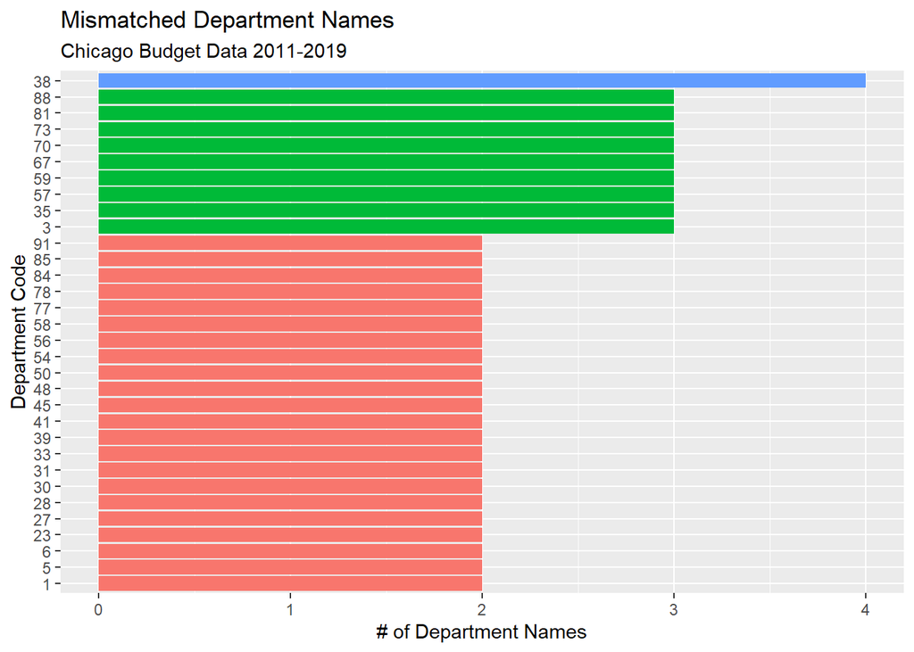

```r
# are department names consistent?
budget %>%
  distinct(`DEPARTMENT DESCRIPTION`,`DEPARTMENT CODE`) %>%
  group_by(`DEPARTMENT CODE`) %>%
  summarise(count = n()) %>%
  filter(count >1) %>%
  ggplot(aes(reorder(`DEPARTMENT CODE`,count),count, fill = as.factor(count))) +
  geom_col() +
  guides(fill=FALSE)+
  coord_flip() +
  labs(title = "Mismatched Department Names", subtitle = "Chicago Budget Data 2011-2019", x= "Department Code",y="# of Department Names")
```

To make it so the department names are consistent across years, we create a CSV file to map the original text and the text we want to change it to. Then a for loop is used to go through every record in the dataset to find and replace based on our mapping CSV file.

```r
# make department names consistent
  ## load the mapping table
  DepartmentNameMap <- read.csv("./input/source/chicago_budget/Department Mapping Table.csv",stringsAsFactors = F)

  ## use the mapping table to replace the production data
    for (row in 1:NROW(DepartmentNameMap)) {
      from <- DepartmentNameMap[row,1]
      to <- DepartmentNameMap[row,2]
      budget$`DEPARTMENT DESCRIPTION` <- str_replace(budget$`DEPARTMENT DESCRIPTION`,from,to)
    }
```

## 2.3 Mismatched Job Titles

For every position there is a human readable job title (“Title Description”) and a unique code (“Title Code”). We can group the records by Title Code to see which codes have multiple human readable names. The histogram below shows that while most title codes have only one human readable job title, some have two or three. These will need to be cleaned up.

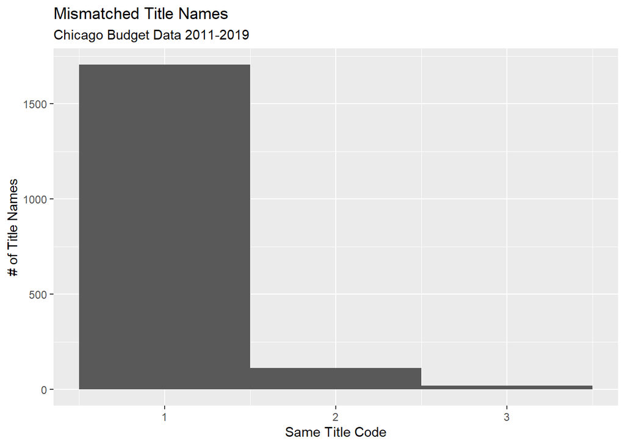

```r
budget %>%
  distinct(`TITLE DESCRIPTION`,`TITLE CODE`) %>%
  group_by(`TITLE CODE`) %>%
  summarise(count = n()) %>%
  ggplot(aes(count)) +
  geom_histogram(bins = 3) +
  labs(title = "Mismatched Title Names", subtitle = "Chicago Budget Data 2011-2019", x= "Same Title Code",y="# of Title Names")
```

### 2.3.1 Matching Approach

The first thing we do is capture all of the Job Codes that have multiple titles associated with them.

```r
JobTitleDupes <- budget %>%
      distinct(`TITLE DESCRIPTION`,`TITLE CODE`) %>%
      group_by(`TITLE CODE`) %>%
      summarise(count = n()) %>%
      filter(count >1) %>% # only codes with multiple job titles
      select(`TITLE CODE`)
```

Now we can take a look at the titles and see some easy patterns like one title being all upper case, others using abbreviations, and appending the title with the department name.

```r
budget %>%
      distinct(`TITLE DESCRIPTION`,`TITLE CODE`) %>%
      group_by(`TITLE CODE`) %>%
      filter(`TITLE CODE` %in% JobTitleDupes$`TITLE CODE`) %>%
      arrange(`TITLE CODE`) %>%
      head(15)
```

```
## # A tibble: 15 x 2
## # Groups:   TITLE CODE [7]
##    `TITLE DESCRIPTION`                   `TITLE CODE`
##    <chr>                                 <chr>
##  1 ELECTRONIC RESOURCES LIBRARIAN        0576
##  2 Electronic Resources Librarian        0576
##  3 Manager of IS Security and Operations 0614
##  4 Informatn Security Mgr                0614
##  5 Information Security Manager          0614
##  6 Technical Support Administrator - IGO 0645
##  7 Technical Support Administrator - IG  0645
##  8 Web Developer/Administrator-CPL       0676
##  9 Web Developer/Administrator - CPL     0676
## 10 IT-Security Specialist                0677
## 11 IT - Security Specialist              0677
## 12 Public Relations Rep I                0701
## 13 Public Relations Representative I     0701
## 14 Public Relations Rep II               0702
## 15 Public Relations Representative II    0702
```

We can export the entire dataframe of Job Title duplicates to a CSV and delete the rows containing names we don’t want, being sure to keep one row with the desired name.

Then, using a for loop, we can replace the Job Title for every record that matches the corresponding Title Code in our mapping file.

```r
 # make job titles consistent
  ## load the mapping table
 JobTitleMap <- read_csv("./input/source/chicago_budget/Job Title Mapping Table.csv")
  ## use the mapping table to replace the production data
    for (row in 1:NROW(JobTitleMap)) {
      TitleDescription <- JobTitleMap[row,1]
      TitleCode <- JobTitleMap[row,2]
 budget[budget$`TITLE CODE` == as.character(TitleCode),"TITLE DESCRIPTION"] <- TitleDescription
    }
```

## 2.4 Saving the Data

Once we’ve finished with our data wrangling we can save our tidy data to a single RDS file and begin our analysis.

```r
# write the output file
write_rds(budget,"./input/source/chicago_budget/Chicago Budget.Rds")
```

# 3 Chicago Budget Analysis

```r
#read data
budget <- read_rds("./input/source/chicago_budget/Chicago Budget.Rds")
```

## 3.1 Total Budget

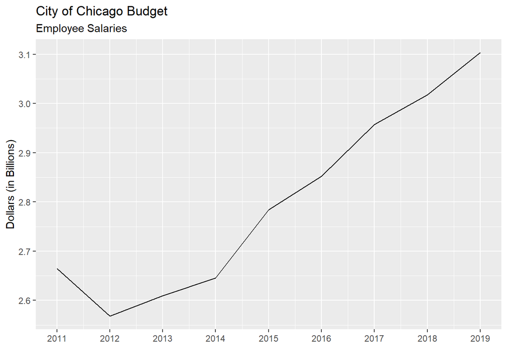

```r
# calculate the total budget by year
budget_summary <- budget %>%
  group_by(YEAR) %>%
  summarize(total =sum(`TOTAL BUDGETED AMOUNT`)/1000000000) %>% #calculate total budget and simplify
  mutate(growth = 100*(total - lag(total))/lag(total)) # how much did the budget grow from previous year?

# chart of total budget over time
budget_summary %>%
  ggplot(aes(YEAR,total)) +
  geom_line() +
  scale_x_continuous(breaks = c(2011:2019)) +
 labs(title = "City of Chicago Budget",subtitle = "Employee Salaries", y="Dollars (in Billions)",x="")
```

## 3.2 Top Departments

By addind up the budgets for all of the years in our dataset, by department, we can see which departments have had the largest budgets.

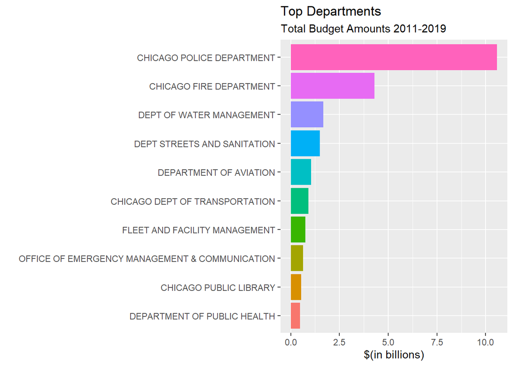

```r
# total budget by department
TopDepartments <- budget %>%
  group_by(Department = `DEPARTMENT DESCRIPTION`) %>%
  summarize(total = sum(`TOTAL BUDGETED AMOUNT`)) %>%
  arrange(desc(total)) %>%
  head(10) %>%
  mutate(total = total/1000000000)

TopDepartments %>%
  ggplot(aes(reorder(Department,total),total, fill = as.factor(total))) +
  geom_col() +
  guides(fill=FALSE)+
  coord_flip() +
  labs(title = "Top Departments", subtitle = "Total Budget Amounts 2011-2019", x= "",y="$(in billions)")
```

Then we can dive deeper into the top 10 departments to see how their budgets have changed over time.

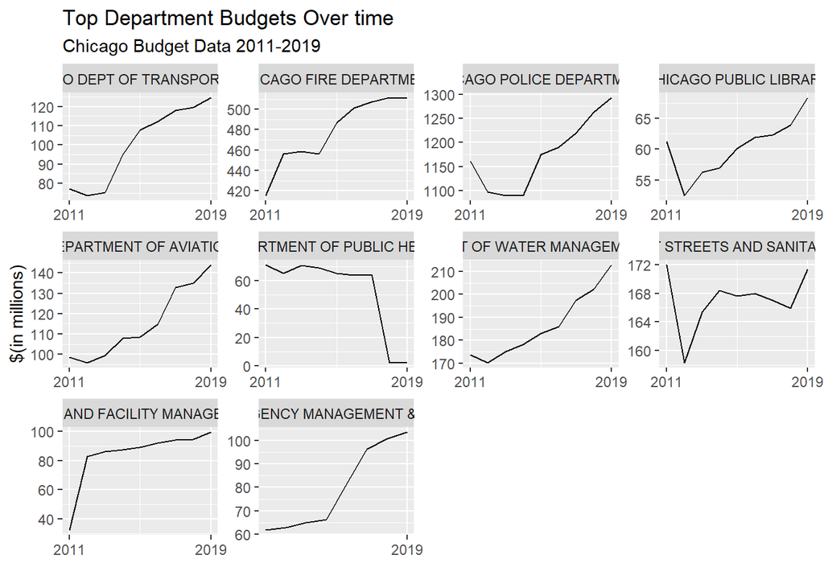

```r
budget[budget$`DEPARTMENT DESCRIPTION` %in% TopDepartments$Department,] %>%

  group_by(Department = `DEPARTMENT DESCRIPTION`,YEAR) %>%
summarise(total = sum(`TOTAL BUDGETED AMOUNT`)) %>%
  mutate(total = total/1000000) %>%
    ggplot(aes(YEAR,total)) +
    geom_line() +
  facet_wrap(~Department, scales = "free") +
   scale_x_continuous(breaks = c(2011,2019)) +
    labs(title = "Top Department Budgets Over time", subtitle = "Chicago Budget Data 2011-2019", x= "",y="$(in millions)")
```

Created by Michael Molloy

*molloytech@gmail.com |* |